# Supervised Learning

All of the datasets used in the examples come from the `OIdata` and `openintro` packages.

```r
# install.packages("devtools")
library(devtools)

install_github("OpenIntroOrg/openintro-r-package", subdir = "OIdata")

install_github("OpenIntroOrg/openintro-r-package", subdir = "openintro")
```

For more information on Open Intro, visit the [website](https://www.openintro.org/) or the [github page](https://github.com/OpenIntroOrg/openintro-r-package) for more information.

# What is regression?

In the statistical sense, regression is predicting an expected value from a set of inputs.

In the causal sense, regression is predicting a numerical outcome which distinguishes it from classification in which you are predicting a discrete outcome such as Yes or No.

We call the expected outcome the “dependent variable”. It is dependent on the inputs, also called the predictors, or “independent variables”.

The fundamental principle of linear regression

Change in Y is linearly proportional to change in X. Each X contributes additively to Y. Y is the sum of all of the weighted inputs.

A linear regression model requires training data and a formula.

In R, you can specify a formula using the tilde `~`. The variable on the left side is always the dpeendent vartiable and isd a function of the right side, the explanatory, or independent value.

```r
library(tidyverse)
library(broom)
library(openintro)
#examine the training data
glimpse(textbooks)
```

```
## Observations: 73
## Variables: 7
## $ deptAbbr <fct> Am Ind, Anthro, Anthro, Anthro, Art His, Art His, Asi...
## $ course   <fct>  C170, 9, 135T, 191HB, M102K, 118E, 187B, 191E, C125,...
## $ ibsn     <fct> 978-0803272620, 978-0030119194, 978-0300080643, 978-0...
## $ uclaNew  <dbl> 27.67, 40.59, 31.68, 16.00, 18.95, 14.95, 24.70, 19.5...
## $ amazNew  <dbl> 27.95, 31.14, 32.00, 11.52, 14.21, 10.17, 20.06, 16.6...
## $ more     <fct> Y, Y, Y, Y, Y, Y, Y, N, N, Y, Y, N, Y, Y, N, N, N, N,...
## $ diff     <dbl> -0.28, 9.45, -0.32, 4.48, 4.74, 4.78, 4.64, 2.84, 17....
```

```r
#create a formula
fmla <- formula('amazNew ~ uclaNew')

#examine the formula
fmla
```

```
## amazNew ~ uclaNew
```

Now that we have a formula we can use it to create a model on our dataset

```r
#create linear model
textbooks_model <- lm(formula = fmla, data = textbooks)

#examine the model
textbooks_model
```

```
##
## Call:
## lm(formula = fmla, data = textbooks)
##
## Coefficients:
## (Intercept)      uclaNew
##      1.0555       0.8087
```

Once you have fit the model, you can examine it various ways.

base R: summary()

```r
summary(textbooks_model)
```

```
##
## Call:
## lm(formula = fmla, data = textbooks)
##
## Residuals:
##     Min      1Q  Median      3Q     Max
## -29.366  -3.101  -1.039   3.322  30.900
##
## Coefficients:
##             Estimate Std. Error t value Pr(>|t|)
## (Intercept)  1.05547    1.58709   0.665    0.508
## uclaNew      0.80869    0.01699  47.599   <2e-16 ***
## ---
## Signif. codes:  0 '***' 0.001 '**' 0.01 '*' 0.05 '.' 0.1 ' ' 1
##
## Residual standard error: 8.601 on 71 degrees of freedom
## Multiple R-squared:  0.9696, Adjusted R-squared:  0.9692
## F-statistic:  2266 on 1 and 71 DF,  p-value: < 2.2e-16
```

using the broom package, the tidy way: glance()

```r
glance(textbooks_model)
```

| r.squared | adj.r.squared | sigma | statistic | p.value | df | logLik | AIC | BIC | deviance | df.residual |
| --- | --- | --- | --- | --- | --- | --- | --- | --- | --- | --- |
| 0.9696148 | 0.9691868 | 8.600528 | 2265.662 | 1.305604e-55 | 2 | -259.6517 | 525.3034 | 532.1747 | 5251.805 | 71 |

Using the stats package (preloaded in R), we can use the `predict` function to find the predicted value for each x based on a specified model.

```r
textbooks$predictions <- predict(object = textbooks_model, newdata = textbooks)

head(textbooks)
```

|  | deptAbbr | course | ibsn | uclaNew | amazNew | more | diff | predictions |
| --- | --- | --- | --- | --- | --- | --- | --- | --- |
| 1 | Am Ind | C170 | 978-0803272620 | 27.67 | 27.95 | Y | -0.28 | 23.43179 |
| 2 | Anthro | 9 | 978-0030119194 | 40.59 | 31.14 | Y | 9.45 | 33.88001 |
| 3 | Anthro | 135T | 978-0300080643 | 31.68 | 32.00 | Y | -0.32 | 26.67462 |
| 4 | Anthro | 191HB | 978-0226206813 | 16.00 | 11.52 | Y | 4.48 | 13.99444 |
| 5 | Art His | M102K | 978-0892365999 | 18.95 | 14.21 | Y | 4.74 | 16.38006 |
| 6 | Art His | 118E | 978-0394723693 | 14.95 | 10.17 | Y | 4.78 | 13.14532 |

Let’s visualize how the predicted values stack up against the observed values

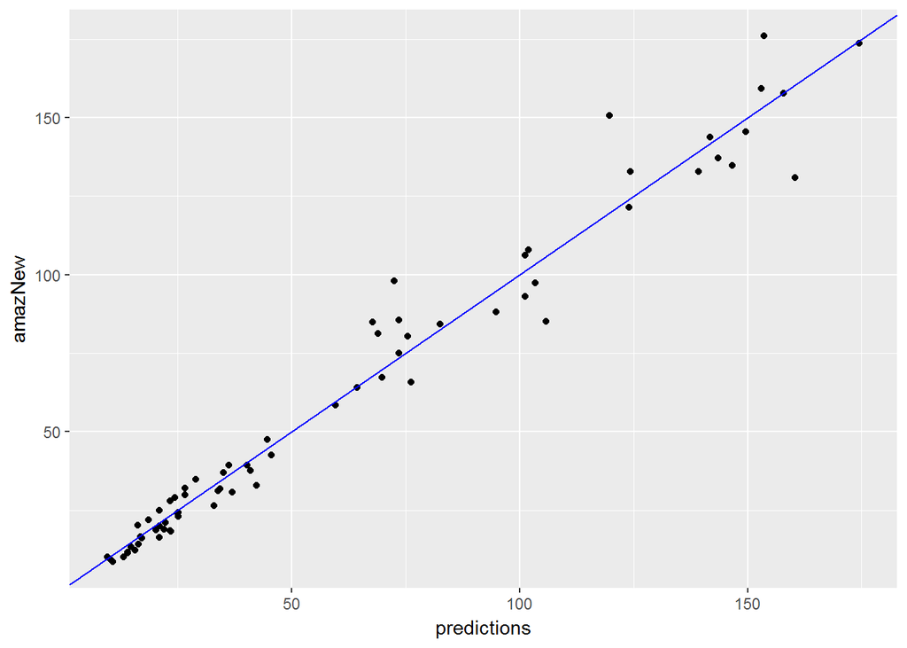

```r
ggplot(textbooks, aes(x = predictions, y = amazNew)) +
  geom_point() +
  geom_abline(color = "blue")
```

And we can use the `predict` function to make a prediction for a new dataset or observation.

```r
#make dataset of new textbooks to make predictions on
new_textbooks <- data.frame(uclaNew = c(65, 142))
```

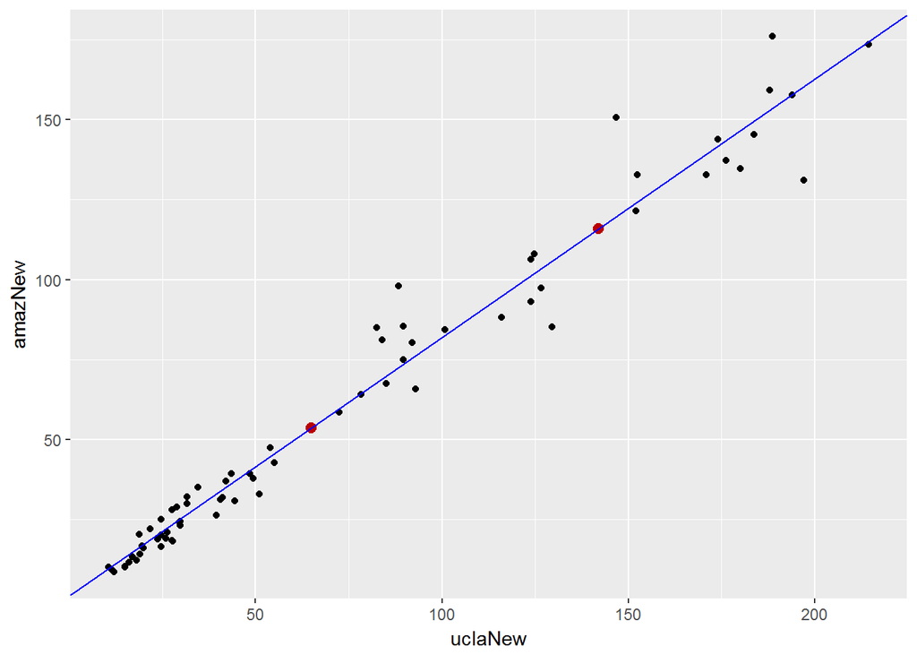

```r
#make Amazon price predictions on the new textbooks based on UCLA price
new_textbooks$amazNew <- predict(object = textbooks_model, newdata = new_textbooks)

#get slope and intercept of original model
intercept <- textbooks_model$coefficients[1]
slope <- textbooks_model$coefficients[2]

#plot results
ggplot(textbooks, aes(x = uclaNew, y = amazNew)) +
  geom_point() +
  geom_point(data = new_textbooks, aes(x = uclaNew, y = amazNew), size = 2.5, color = "#ba0000") +
  geom_abline(intercept = intercept, slope = slope, color = "blue")
```

**Pros of Linear Regression**

- Easy to fit and apply
- Concise - (don’t need much storage)
- Less prone to overfitting (training and test data usually behave similarly)
- Interpretable

**Cons**

- Can only express linear and additive relationships
- Colinearity
  - input variables are partially correlated (weight and age)
  - coefficients might change sign
  - coefficients (or standard errors) look too large
  - model may be unstable

# Model Evaluation

**The following section will explain the parameters which are used to evaluate a model’s performance.**

We will use the `bac` dataset which analyzes the relationship between the blood alcohol content (bac) and number of beers drank for 16 students.

```r
glimpse(bac)
```

```
## Observations: 16
## Variables: 3
## $ Student <int> 1, 2, 3, 4, 5, 6, 7, 8, 9, 10, 11, 12, 13, 14, 15, 16
## $ Beers   <int> 5, 2, 9, 8, 3, 7, 3, 5, 3, 5, 4, 6, 5, 7, 1, 4
## $ BAC     <dbl> 0.100, 0.030, 0.190, 0.120, 0.040, 0.095, 0.070, 0.060...
```

```r
#model the grades as a function of TV
bac_mod <- lm(BAC ~ Beers, bac)

glance(bac_mod)
```

| r.squared | adj.r.squared | sigma | statistic | p.value | df | logLik | AIC | BIC | deviance | df.residual |
| --- | --- | --- | --- | --- | --- | --- | --- | --- | --- | --- |
| 0.7998407 | 0.7855436 | 0.02044095 | 55.9443 | 2.96948e-06 | 2 | 40.60867 | -75.21735 | -72.89958 | 0.005849655 | 14 |

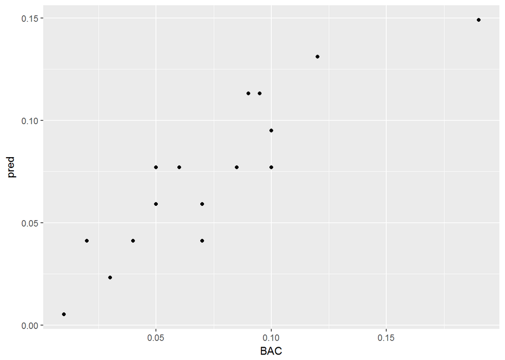

```r
bac$pred <- predict(bac_mod, bac)

ggplot(bac, aes(x = BAC, y = pred)) +
  geom_point()
```

### Residuals

The **residuals** Tell you how far off the actual value is from the predicted value. They can also tell you whether there are correlations in your data still unaccounted for. You should expect to see no systematic errors in the plot of the residuals meaning that the amount of error is consistent and random for the entire dataset.

The residual for any obervation is calcualted as the difference between the actual and predicted value.

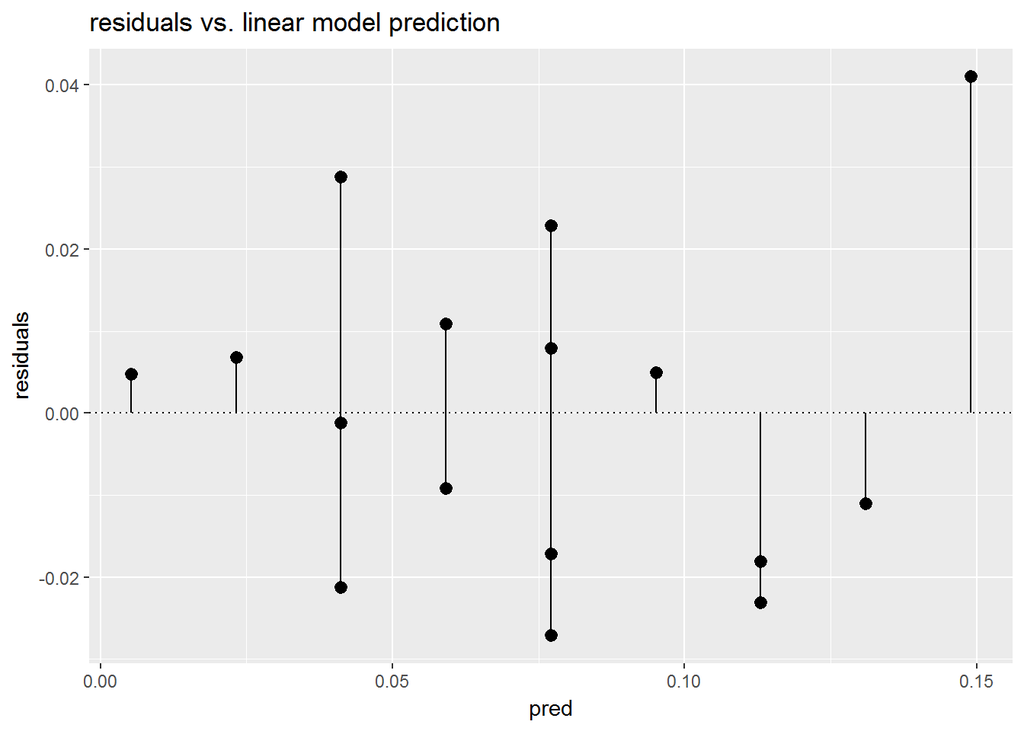

```r
bac$residuals <- bac$BAC - bac$pred

ggplot(bac, aes(x = pred, y = residuals)) +
  geom_pointrange(aes(ymin= 0, ymax = residuals)) +
  geom_hline(yintercept = 0, linetype = 3) +
  ggtitle("residuals vs. linear model prediction")
```

### Gain Curve

**Gain Curve** viualizes the sort order of the predictions. The y-axis plots the cumulative sum of the response variable as a fraction and the x-axis plots the numbers of observations as a fraction. This is useful in situations where the sort order is more important than the actual values.

Use the `WVPlots` package for the gain curve function.

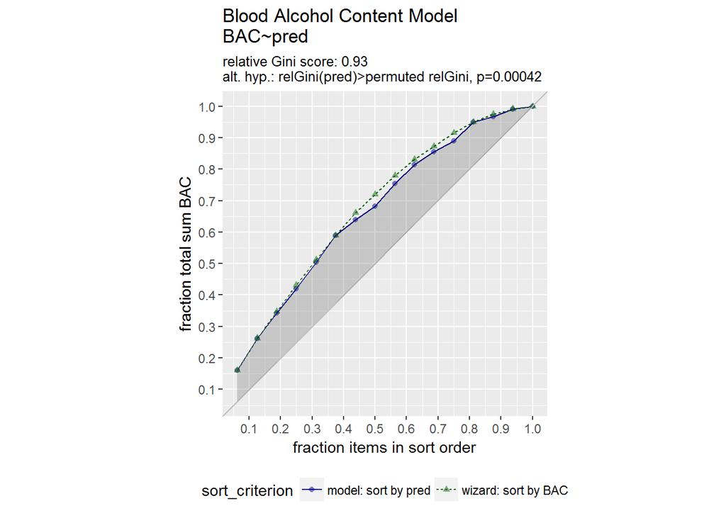

```r
library(WVPlots)

GainCurvePlot(frame = bac, xvar = "pred", truthVar = "BAC", title = "Blood Alcohol Content Model")
```

### RMSE

**Root Mean Squared Error*. How much error is associated with the prediction values compared to the actual values. You can compare the RMSE to the SD of the actual values to get an idea of how well your model is at predicting the values.

The RMSE is calculated as

$$RMSE = \sqrt{mean(residual^2)}$$

```r
#calculate RMSE
sqrt(mean(bac$residuals^2))
```

```
## [1] 0.01912076
```

```r
#calculate sd of the original data
sd(bac$BAC)
```

```
## [1] 0.04413993
```

### $R^2$

The $R^2$ is a measure of the goodness of fit, or rather, how well does your model explain the data? The $R^2$ value ranges between 0 - 1. A value of 0 means that you’d be better off guessing what the estimated value would be. A value of 1 means the model fits well and that you’ve accounted for all the variation in the data.

$$R^2 = 1 - {RSS \over SS_{tot}}$$
where

RSS is the residual sum of squares (the variance from the model)
$$RSS = \sum(y - prediction)^2$$
and

TSS is the total sum of squares (the variance from the data)
$$SS_{tot} = \sum(y - \bar y)^2$$

```r
#calculate rss
rss <- sum((bac$BAC - bac$pred)^2)

#calculate tss
tss <- sum((bac$BAC - mean(bac$BAC))^2)

#calculate r_squared
r_squared <- 1 - (rss/tss)

#compare r_squared to the r_squared from glance() function and from the correlation coefficient
r_squared
```

```
## [1] 0.7998407
```

```r
glance(bac_mod)$r.squared
```

```
## [1] 0.7998407
```

```r
rho <- cor(y = bac$BAC, x = bac$pred)
rho^2
```

```
## [1] 0.7998407
```

## Model Training

In general, a model performs much better on the training data than on data the model has not yet seen.

It is common to split the dataset into a **training/test** set. This is recommended when the data is plentiful.

**Test/Train splitting tests the final model**

The following examples use the `diamonds` dataset, part of the `ggplot2` package.

```r
#model the data (price vs. carat)
glimpse(diamonds)
```

```
## Observations: 53,940
## Variables: 10
## $ carat   <dbl> 0.23, 0.21, 0.23, 0.29, 0.31, 0.24, 0.24, 0.26, 0.22, ...
## $ cut     <fct> Ideal, Premium, Good, Premium, Good, Very Good, Very G...
## $ color   <fct> E, E, E, I, J, J, I, H, E, H, J, J, F, J, E, E, I, J, ...
## $ clarity <fct> SI2, SI1, VS1, VS2, SI2, VVS2, VVS1, SI1, VS2, VS1, SI...
## $ depth   <dbl> 61.5, 59.8, 56.9, 62.4, 63.3, 62.8, 62.3, 61.9, 65.1, ...
## $ table   <dbl> 55, 61, 65, 58, 58, 57, 57, 55, 61, 61, 55, 56, 61, 54...
## $ price   <int> 326, 326, 327, 334, 335, 336, 336, 337, 337, 338, 339,...
## $ x       <dbl> 3.95, 3.89, 4.05, 4.20, 4.34, 3.94, 3.95, 4.07, 3.87, ...
## $ y       <dbl> 3.98, 3.84, 4.07, 4.23, 4.35, 3.96, 3.98, 4.11, 3.78, ...
## $ z       <dbl> 2.43, 2.31, 2.31, 2.63, 2.75, 2.48, 2.47, 2.53, 2.49, ...
```

```r
#get the number of rows in bac
nrows <- nrow(diamonds)

#calculate 75% of the nrows
target <- round(0.75 * nrows)

#generate a vector of nrow uniform random variables
gp <- runif(n = nrows)

#split the data into test/training sets
train <- diamonds[gp <  0.75, ]
test <- diamonds[gp > .75, ]

nrow(train)
```

```
## [1] 40432
```

```r
nrow(test)
```

```
## [1] 13508
```

```r
#create model useing training data
dmnds_mod <- lm(price ~ carat, train)

summary(dmnds_mod)
```

```
##
## Call:
## lm(formula = price ~ carat, data = train)
##
## Residuals:
##      Min       1Q   Median       3Q      Max
## -14493.0   -807.2    -21.2    540.5  12735.0
##
## Coefficients:
##             Estimate Std. Error t value Pr(>|t|)
## (Intercept) -2257.21      15.08  -149.7   <2e-16 ***
## carat        7754.07      16.27   476.6   <2e-16 ***
## ---
## Signif. codes:  0 '***' 0.001 '**' 0.01 '*' 0.05 '.' 0.1 ' ' 1
##
## Residual standard error: 1548 on 40430 degrees of freedom
## Multiple R-squared:  0.8489, Adjusted R-squared:  0.8489
## F-statistic: 2.272e+05 on 1 and 40430 DF,  p-value: < 2.2e-16
```

```r
#predict price from carat on the training set
train$pred <- predict(dmnds_mod, train)

#predict price from carat on the test set
test$pred <- predict(dmnds_mod, test)

#Evaluate the RMSE for each
rmse <- function(predcol, ycol) {
  res <- predcol- ycol
  sqrt(mean(res^2))
}

(rmse_train <- rmse(train$pred, train$price))
```

```
## [1] 1547.708
```

```r
(rmse_test <- rmse(test$pred, test$price))
```

```
## [1] 1551.01
```

```r
#evaluate the $R^2$ for each
rsq <- function(predcol, ycol) {
  tss = sum( (ycol - mean(ycol))^2 )
  rss = sum( (predcol - ycol)^2 )
  1 - rss/tss
}

(rsq_train <- rsq(train$pred, train$price))
```

```
## [1] 0.8489129
```

```r
(rsq_test <- rsq(test$pred, test$price))
```

```
## [1] 0.8505528
```

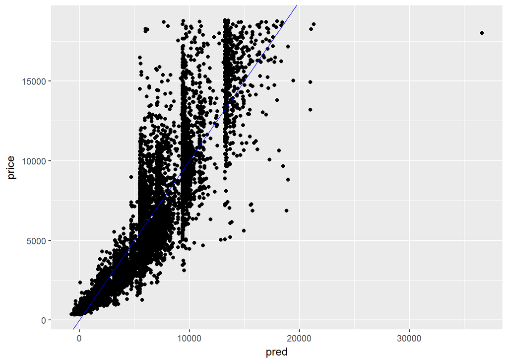

```r
#plot the predicted vs. the outcome for the test data
ggplot(test, aes(x = pred, y = price))+
  geom_point() +
  geom_abline(color = "blue")
```

If the data set does not have enough data to split off a test set, the **cross-validation** method is preferred.

One way of creating a cross-validation plan is to use the `kWayCrossValidation` function from the `vtreat` package.

**Cross-validation tests the modeling process**

The following examples use the `helmet` dataset from the `openintro` package. The helmet dataset describes the relationship between socioeconomic status measured as the percentage of children in a neighborhood receiving reduced-fee lunches at school(lunch) and the percentage of bike riders in the neighborhood wearing helmets (helmet).

```r
#install.packages("vtreat")
library(vtreat)

#load helmet dataset from openintro


#examine the helmet dataset
glimpse(helmet)
```

```
## Observations: 12
## Variables: 2
## $ lunch  <int> 50, 11, 2, 19, 26, 73, 81, 51, 11, 2, 19, 25
## $ helmet <dbl> 22.1, 35.9, 57.9, 22.2, 42.4, 5.8, 3.6, 21.4, 55.2, 33....
```

```r
#count nrows of helmet
helmet_rows <- nrow(helmet)

#create cross-validtion model with 3-folds
splits <- kWayCrossValidation(nRows = helmet_rows, nSplits = 3)

#examine splits
str(splits)
```

```
## List of 3
##  $ :List of 2
##   ..$ train: int [1:8] 1 2 3 4 6 8 10 11
##   ..$ app  : int [1:4] 5 12 9 7
##  $ :List of 2
##   ..$ train: int [1:8] 3 5 6 7 9 10 11 12
##   ..$ app  : int [1:4] 1 4 2 8
##  $ :List of 2
##   ..$ train: int [1:8] 1 2 4 5 7 8 9 12
##   ..$ app  : int [1:4] 10 6 3 11
##  - attr(*, "splitmethod")= chr "kwaycross"
```

```r
#run the 3-fold cross-validation plan on the data
helmet$cv_pred <- 0

for(i in 1:3){
  split <- splits[[i]]
  model <- lm(lunch ~ helmet, helmet[split$train, ])
  helmet$cv_pred[split$app] <- predict(model, helmet[split$app, ])
}

#predict from a full model
helmet$pred <- predict(lm(lunch ~ helmet, helmet))

#get RMSE of full model and CV set
rmse(helmet$pred, helmet$lunch)
```

```
## [1] 13.50846
```

```r
rmse(helmet$cv_pred, helmet$lunch)
```

```
## [1] 16.06373
```

# Issues to Consider

## categorical variables

**categorical variables** - one-hot-coding

The model will leave out one of the categories as this is the reference-level. The coefficient value tells you the change expected when all other variables are 0 relative to the reference level.

## Interactions

**interactions**

Recall that linear regression assumes an additive relationship between variables.

plant height ~ sunlight + bacteria

Change in height is the sum of the effects of bacteria and light. Therefore, Change in sunlight causes the same change in height, independent of bacteria. And also, change in bactera causes the same change in height, independent of sunlight.

**An interaction occurs when the simultaneous influence of two variables on the outcome is not additive.**

In a formula, you can specify interacion with a colon (:)

`y ~ a:b`

You can specify main effects AND interaction with an asterisk (*)

`y ~ a*b`

is the same as

`y ~ a + b + a:b`

And finally, you can express the product of two variables using: I(*)

`y ~ I(a*b)`

## Transformations

log transformations are usueful in monetary values. Often have wide dynamic range and long tails.

# Dealing with Non-Linear Responses

### logistic regression

Predicting whether an even occurs (yes/no) fals into the realm of classification.

However, predicting the probability that an event occurs is regression.

For the latter, we can use **logistic regression**, which assumes inputs are additive, and linear in log-odds. The log-odds is the ratio between the probability of an event occurring to the probability of the event not occurring.

The `glm` function is used for logistic regression and functions similarly to the `lm` function with the addition of the `family` argument. For logistic regression, the family argument will be set to **binomial**.

To evaluate a logistic regression model, the deviance and pseudo $R^2$ are used. The deviance is similar to the variance.

### poisson and quasipoisson regression

### GAM

Generalized Additive Models.

`mgcv` package for the `gam` function.

`s()` function to denote a non-linear relationship of a ocntinuous variable in your formula.

```r
#install.packages("mgcv")
library(lubridate)
library(mgcv)
#exmaine the data
glimpse(goog)
```

```
## Observations: 98
## Variables: 7
## $ Date      <fct> 2014-02-03, 2014-01-02, 2013-12-02, 2013-11-01, 2013...
## $ Open      <dbl> 1179.20, 1115.46, 1063.51, 1031.79, 880.25, 854.36, ...
## $ High      <dbl> 1212.87, 1186.54, 1121.00, 1068.00, 1041.52, 905.99,...
## $ Low       <dbl> 1128.02, 1082.27, 1049.02, 1005.00, 842.98, 853.95, ...
## $ Close     <dbl> 1203.79, 1180.97, 1120.71, 1059.59, 1030.58, 875.91,...
## $ Volume    <int> 2409900, 2860800, 1675400, 1372400, 2472300, 1742200...
## $ Adj.Close <dbl> 1203.79, 1180.97, 1120.71, 1059.59, 1030.58, 875.91,...
```

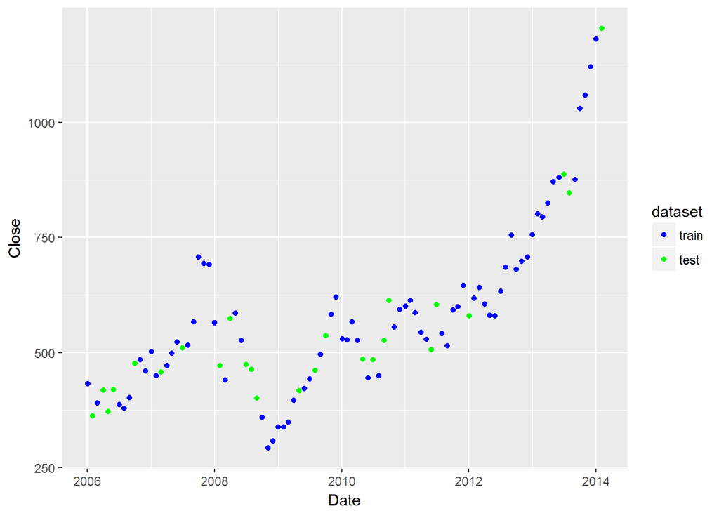

```r
#convert date variable to date format
goog$Date <- as_date(goog$Date)

#convert date variable to continuous sequence
#for comptability with splining in formula
goog$d <- seq(from = nrow(goog), to = 1)

#split data into train and test sets
n <- nrow(goog)

sample <- sample.int(n = n, size = floor(0.75 * n), replace = F)

goog_train <- goog[sample, ]
goog_test <- goog[-sample, ]


#visualize the variables of interest in the training set
ggplot(goog, aes(x = Date)) +
  geom_point(data = goog_train, aes(y = Close, color = "blue")) +
  geom_point(data = goog_test, aes (y = Close, color = "green")) +
  scale_color_manual(name = "dataset", values = c('blue' = 'blue', 'green' = 'green'), labels = c("train", "test"))
```

```r
#Fit GAM model on training set
model.gam <- gam(formula = Close ~ s(d), data = goog_train, family = gaussian)

#fit lm model on training set and compare
model.lm <- lm(formula = Close ~ d, data = goog_train)

summary(model.gam)
```

```
##
## Family: gaussian
## Link function: identity
##
## Formula:
## Close ~ s(d)
##
## Parametric coefficients:
##             Estimate Std. Error t value Pr(>|t|)
## (Intercept)  588.405      6.192   95.02   <2e-16 ***
## ---
## Signif. codes:  0 '***' 0.001 '**' 0.01 '*' 0.05 '.' 0.1 ' ' 1
##
## Approximate significance of smooth terms:
##        edf Ref.df     F p-value
## s(d) 8.712  8.975 90.16  <2e-16 ***
## ---
## Signif. codes:  0 '***' 0.001 '**' 0.01 '*' 0.05 '.' 0.1 ' ' 1
##
## R-sq.(adj) =  0.918   Deviance explained = 92.8%
## GCV = 3228.9  Scale est. = 2799.3    n = 73
```

```r
summary(model.lm)
```

```
##
## Call:
## lm(formula = Close ~ d, data = goog_train)
##
## Residuals:
##     Min      1Q  Median      3Q     Max
## -214.55  -83.41  -29.06   75.85  379.14
##
## Coefficients:
##             Estimate Std. Error t value Pr(>|t|)
## (Intercept) 341.3541    31.7391  10.755  < 2e-16 ***
## d             4.7472     0.5375   8.832  4.8e-13 ***
## ---
## Signif. codes:  0 '***' 0.001 '**' 0.01 '*' 0.05 '.' 0.1 ' ' 1
##
## Residual standard error: 128.1 on 71 degrees of freedom
## Multiple R-squared:  0.5235, Adjusted R-squared:  0.5168
## F-statistic: 78.01 on 1 and 71 DF,  p-value: 4.797e-13
```

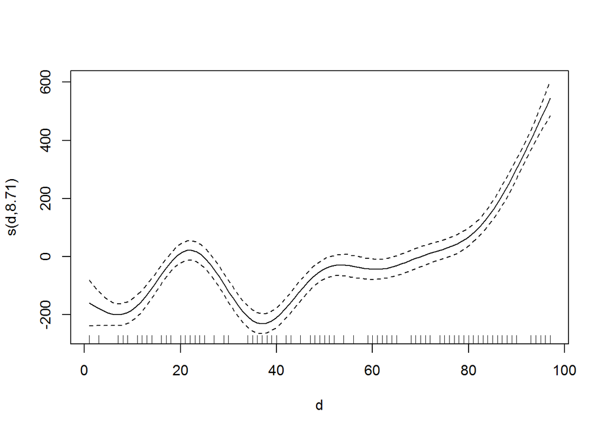

```r
plot(model.gam)
```

```r
#get predictions for linear model
goog_test$pred.lm <- predict(model.lm, goog_test)

#get predicitons from gam model
#use as.numeric to convert matrix output to vector
goog_test$pred.gam <- as.numeric(predict(model.gam, goog_test))

#gather predictions into a long dataset
goog_long <- goog_test %>%
  gather(key = modeltype, value = prediction, ... = pred.lm, pred.gam)

#calculate the rmse
goog_long %>%
  mutate(residual = Close - prediction) %>%
  group_by(modeltype) %>%
  summarise(rmse = sqrt(mean(residual^2)))
```

| modeltype | rmse |
| --- | --- |
| pred.gam | 52.91185 |
| pred.lm | 111.37533 |

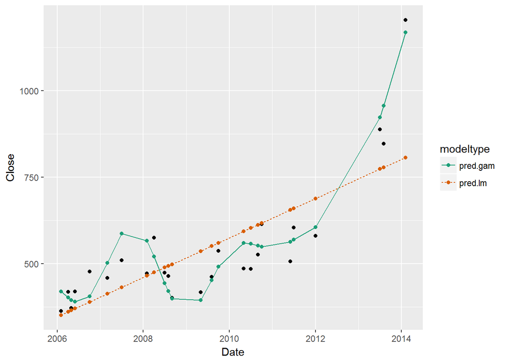

```r
goog_long %>%
  ggplot(aes(x = Date)) +
  geom_point(aes(y = Close)) +
  geom_point(aes(y = prediction, color = modeltype)) +
  geom_line(aes(y = prediction, color = modeltype, linetype = modeltype)) +
  scale_color_brewer(palette = "Dark2")
```